# Lab6

1. Створити програму для генерації довільного неспадаючого масиву із 100 цілих чисел, які не перевищують по модулю 255, з наступними властивостями: 1.1. При кожному запуску програми масив повинен бути різним. 1.2. Масив повинен містити 10 елементів з однаковим значенням a в довільному місці (a випадкове значення із [1, 254]). 1.3. Масив повинен містити 20 елементів з однаковим значенням b в довільному місці (b≠a, випадкове значення із [1, 254]). 1.4. a та b задає користувач.

```python
import random

def generate_array(a, b):
    if a == b or not (1 <= a <= 254) or not (1 <= b <= 254):
        raise ValueError("a і b повинні бути різними та належати діапазону [1, 254]")

    # Генеруємо 70 випадкових чисел із діапазону [-255, 255] виключаючи значення a і b
    random_numbers = [random.choice([i for i in range(1, 256) if i != a and i != b]) for _ in range(70)]

    # Додаємо 10 чисел a і 20 чисел b
    array = random_numbers + [a] * 10 + [b] * 20

    # Перемішуємо масив
    random.shuffle(array)

    # Сортуємо масив за неспаданням
    array.sort()
    random.shuffle(array)

    return array

# Введення значень a та b від користувача
# a = int(input("Введіть значення a (від 1 до 254): "))
# b = int(input("Введіть значення b (від 1 до 254): "))

a = 10
b = 80

# Генерація масиву
result_array = generate_array(a, b)

# Виведення результату
print("Згенерований масив:", result_array)
```

```
Згенерований масив: [10, 63, 130, 80, 80, 80, 80, 10, 10, 10, 81, 153, 185, 171, 10, 80, 184, 126, 91, 112, 80, 180, 101, 82, 20, 14, 146, 80, 80, 201, 10, 85, 80, 224, 242, 1, 185, 72, 15, 162, 80, 170, 80, 67, 150, 80, 39, 74, 80, 237, 236, 80, 103, 218, 224, 235, 10, 71, 233, 10, 167, 82, 166, 22…
```

Зберегти згенерований масив в файл.

```python
def save_array_to_file(array, filename):
    # Записуємо масив у файл
    with open(filename, 'w') as file:
        for num in array:
            file.write(f"{num}\n")

# Зберігаємо масив у файл
save_array_to_file(result_array, 'output_array.txt')
print(f"Масив збережено у файл 'output_array.txt'")
```

```
Масив збережено у файл 'output_array.txt'
```

3. Створити програму, яка зчитує із файлу згенерований масив попередньою програмою і виводить його на екран.

```python
def read_array_from_file(filename):
    # Читаємо масив з файлу
    with open(filename, 'r') as file:
        array = [int(line.strip()) for line in file]
    return array

# Ім'я файлу, з якого будемо читати масив
filename = 'output_array.txt'

# Читаємо масив з файлу
array_from_file = read_array_from_file(filename)

# Виводимо зчитаний масив на екран
print("Зчитаний масив з файлу:", array_from_file)
```

```
Зчитаний масив з файлу: [10, 63, 130, 80, 80, 80, 80, 10, 10, 10, 81, 153, 185, 171, 10, 80, 184, 126, 91, 112, 80, 180, 101, 82, 20, 14, 146, 80, 80, 201, 10, 85, 80, 224, 242, 1, 185, 72, 15, 162, 80, 170, 80, 67, 150, 80, 39, 74, 80, 237, 236, 80, 103, 218, 224, 235, 10, 71, 233, 10, 167, 82, 166…
```

4. Візуалізувати масив за допомогою діаграми типу графік. Виділити кольором рівень, який відповідає значению a, а також вказати значення на діаграмі. Виділити іншим кольором рівень, який відповідає значению b, а також вказати значення на діаграмі.

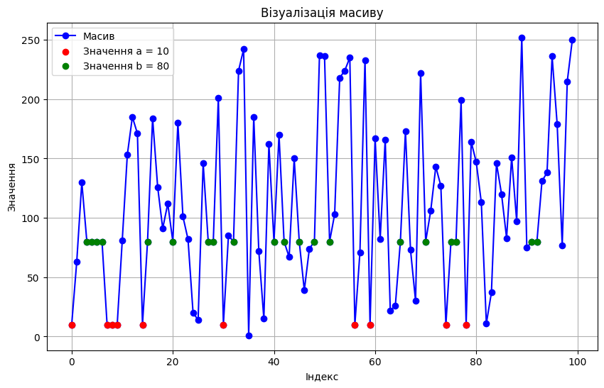

```python
import matplotlib.pyplot as plt


def visualize_array(array, a, b):
    # Створюємо графік
    plt.figure(figsize=(10, 6))
    x = range(len(array))  # Значення x - індекси елементів масиву

    # Будуємо графік для всього масиву
    plt.plot(x, array, label="Масив", color='blue', marker='o')

    # Виділяємо рівень для a
    a_indices = [i for i, value in enumerate(array) if value == a]
    plt.scatter(a_indices, [a] * len(a_indices), color='red', label=f"Значення a = {a}", zorder=5)

    # Виділяємо рівень для b
    b_indices = [i for i, value in enumerate(array) if value == b]
    plt.scatter(b_indices, [b] * len(b_indices), color='green', label=f"Значення b = {b}", zorder=5)

    # Підписуємо осі
    plt.xlabel("Індекс")
    plt.ylabel("Значення")

    # Підписуємо діаграму
    plt.title("Візуалізація масиву")

    # Додаємо легенду
    plt.legend()

    # Показуємо графік
    plt.grid(True)
    plt.show()


# Візуалізуємо масив
visualize_array(array_from_file, a, b)
```

5. Порахувати кількість та суму елементів масиву, розташованих між елементами a та b.

```python
def count_and_sum_between_a_b(array, a, b):
    # Переконаємося, що a < b для коректної логіки
    if a > b:
        a, b = b, a

    # Знайдемо елементи між значеннями a і b
    elements_between = [x for x in array if a < x < b]

    # Кількість елементів
    count = len(elements_between)

    # Сума елементів
    total_sum = sum(elements_between)

    return count, total_sum

# Підраховуємо кількість та суму елементів між a та b
count, total_sum = count_and_sum_between_a_b(array_from_file, a, b)

# Виведення результату
print(f"Кількість елементів між {a} і {b}: {count}")
print(f"Сума елементів між {a} і {b}: {total_sum}")
```

```
Кількість елементів між 10 і 80: 17
Сума елементів між 10 і 80: 786
```

6. Порахувати середнє значення елементів масиву, розташованих до елемента a, середнє значення елементів масиву, розташованих між a та b, середнє значення елементів масиву, розташованих після елементу b. Вказати відповідні рівні на діаграмі.

```
Середнє значення елементів до a = 1.00
Середнє значення елементів між a та b = 46.24
Середнє значення елементів після b = 162.58
```

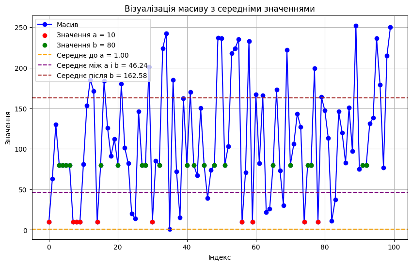

```python
import matplotlib.pyplot as plt


def calculate_means(array, a, b):
    if a > b:
        a, b = b, a

    # Елементи до a
    elements_before_a = [x for x in array if x < a]

    # Елементи між a і b
    elements_between_a_b = [x for x in array if a < x < b]

    # Елементи після b
    elements_after_b = [x for x in array if x > b]

    # Середні значення
    mean_before_a = sum(elements_before_a) / len(elements_before_a) if elements_before_a else None
    mean_between_a_b = sum(elements_between_a_b) / len(elements_between_a_b) if elements_between_a_b else None
    mean_after_b = sum(elements_after_b) / len(elements_after_b) if elements_after_b else None

    return mean_before_a, mean_between_a_b, mean_after_b

def visualize_means_with_levels(array, a, b, mean_before_a, mean_between_a_b, mean_after_b):
    plt.figure(figsize=(10, 6))
    x = range(len(array))  # Індекси елементів масиву

    # Будуємо графік для всього масиву
    plt.plot(x, array, label="Масив", color='blue', marker='o')

    # Виділяємо рівень для a
    a_indices = [i for i, value in enumerate(array) if value == a]
    plt.scatter(a_indices, [a] * len(a_indices), color='red', label=f"Значення a = {a}", zorder=5)

    # Виділяємо рівень для b
    b_indices = [i for i, value in enumerate(array) if value == b]
    plt.scatter(b_indices, [b] * len(b_indices), color='green', label=f"Значення b = {b}", zorder=5)

    # Додаємо горизонтальні лінії для середніх значень
    if mean_before_a is not None:
        plt.axhline(y=mean_before_a, color='orange', linestyle='--', label=f"Середнє до a = {mean_before_a:.2f}")

    if mean_between_a_b is not None:
        plt.axhline(y=mean_between_a_b, color='purple', linestyle='--', label=f"Середнє між a і b = {mean_between_a_b:.2f}")

    if mean_after_b is not None:
        plt.axhline(y=mean_after_b, color='brown', linestyle='--', label=f"Середнє після b = {mean_after_b:.2f}")

    # Підписуємо осі
    plt.xlabel("Індекс")
    plt.ylabel("Значення")

    # Підписуємо діаграму
    plt.title("Візуалізація масиву з середніми значеннями")

    # Додаємо легенду
    plt.legend()

    # Показуємо графік
    plt.grid(True)
    plt.show()


# Обчислюємо середні значення
mean_before_a, mean_between_a_b, mean_after_b = calculate_means(array_from_file, a, b)

# Виведення середніх значень
print(f"Середнє значення елементів до a = {mean_before_a:.2f}" if mean_before_a is not None else "Немає елементів до a.")
print(f"Середнє значення елементів між a та b = {mean_between_a_b:.2f}" if mean_between_a_b is not None else "Немає елементів між a та b.")
print(f"Середнє значення елементів після b = {mean_after_b:.2f}" if mean_after_b is not None else "Немає елементів після b.")

# Візуалізуємо масив з рівнями середніх значень
visualize_means_with_levels(array_from_file, a, b, mean_before_a, mean_between_a_b, mean_after_b)
```

7. Побудувати діаграму яка містить мінімальний елемент, пораховані значення в пункті 6, значення a та b, максимальний елемент.

```
Мінімальний елемент: 1
Максимальний елемент: 252
Середнє значення елементів до a = 1.00
Середнє значення елементів між a та b = 46.24
Середнє значення елементів після b = 162.58
```

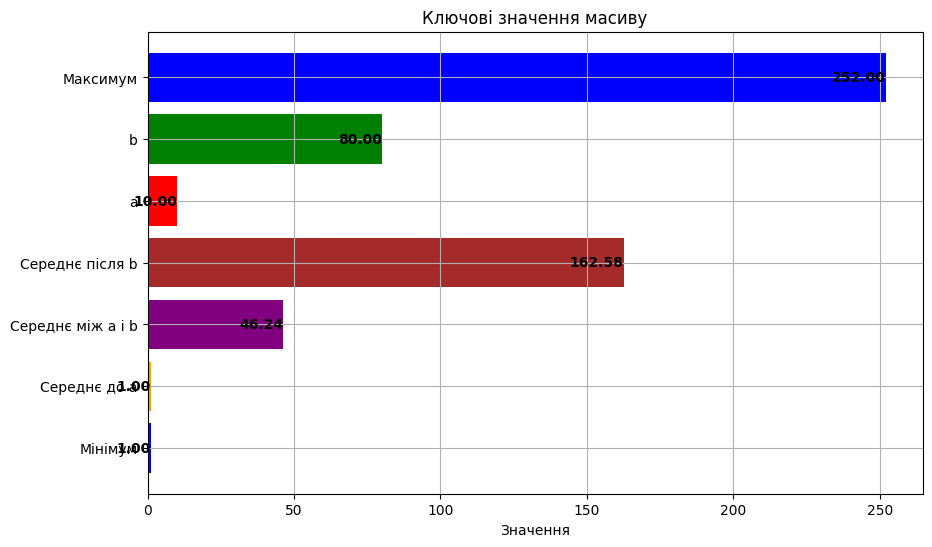

```python
import matplotlib.pyplot as plt


def build_summary_chart(min_value, mean_before_a, mean_between_a_b, mean_after_b, a, b, max_value):
    # Значення, які будемо відображати на діаграмі
    values = [min_value, mean_before_a, mean_between_a_b, mean_after_b, a, b, max_value]
    labels = ['Мінімум', 'Середнє до a', 'Середнє між a і b', 'Середнє після b', 'a', 'b', 'Максимум']

    # Фільтруємо None значення
    filtered_values = [v for v in values if v is not None]
    filtered_labels = [labels[i] for i in range(len(values)) if values[i] is not None]

    # Побудова горизонтальної діаграми
    plt.figure(figsize=(10, 6))
    plt.barh(filtered_labels, filtered_values, color=['blue', 'orange', 'purple', 'brown', 'red', 'green', 'blue'])

    # Додаємо значення над кожною смугою
    for index, value in enumerate(filtered_values):
        plt.text(value, index, f'{value:.2f}', va='center', ha='right', color='black', fontweight='bold')

    # Налаштування осей
    plt.xlabel('Значення')
    plt.title('Ключові значення масиву')
    plt.grid(True)

    # Відображення діаграми
    plt.show()

# Обчислюємо середні значення
mean_before_a, mean_between_a_b, mean_after_b = calculate_means(array_from_file, a, b)

# Знаходимо мінімум та максимум
min_value = min(array_from_file)
max_value = max(array_from_file)

# Виводимо ключові значення
print(f"Мінімальний елемент: {min_value}")
print(f"Максимальний елемент: {max_value}")
print(f"Середнє значення елементів до a = {mean_before_a:.2f}" if mean_before_a is not None else "Немає елементів до a.")
print(f"Середнє значення елементів між a та b = {mean_between_a_b:.2f}" if mean_between_a_b is not None else "Немає елементів між a та b.")
print(f"Середнє значення елементів після b = {mean_after_b:.2f}" if mean_after_b is not None else "Немає елементів після b.")

# Побудова діаграми
build_summary_chart(min_value, mean_before_a, mean_between_a_b, mean_after_b, a, b, max_value)
```